# stat420 final proj

## Discussion

We were able to improve our model based on adding more relative predictors to the existing model. We evaluated the prediction of minimum temperature in Canberra, which would be helpful for us to prepare clothes when traveling based on different weather conditions. Also, agriculture could be benefited from this prediction. There are many missing values in the dataset which may cause the result to be inaccurate. There are only 328 values in a total of 365 days, which means there’s possibility that not all possible conditions are considered in the dataset.

## Appendix

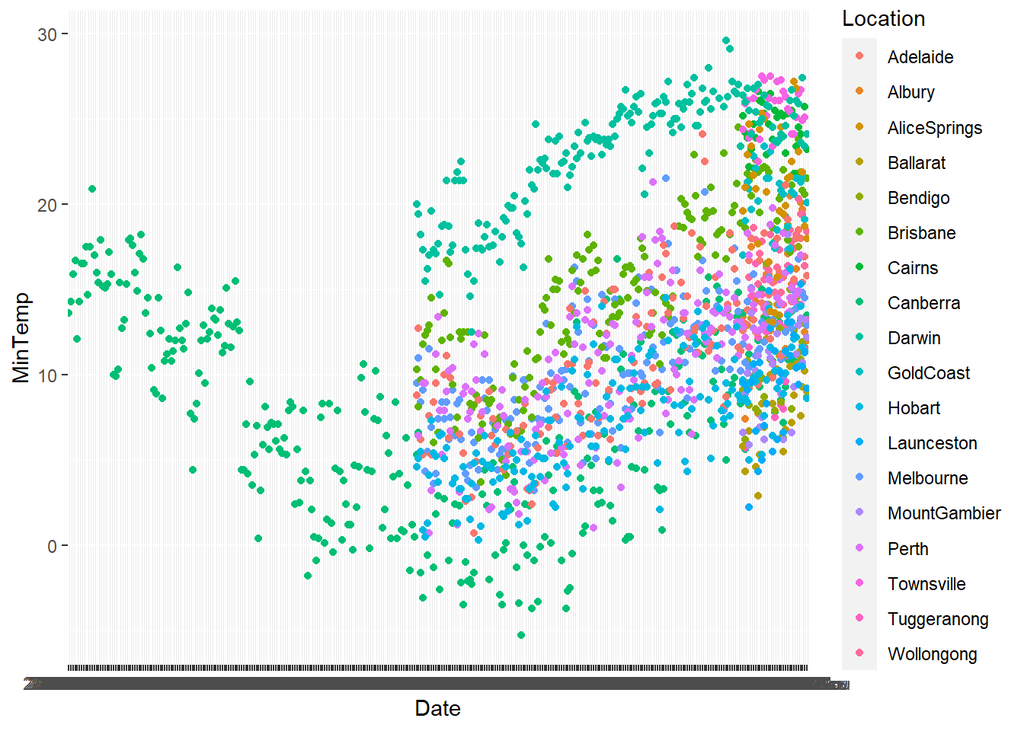

```r
ggplot(data = weather, aes(x = Date, y = MinTemp, color=Location))+geom_point()
```

### Summary of model 2

```r
summary(select_2)
```

```
##
## Call:
## lm(formula = MinTemp ~ RainToday + MaxTemp + Pressure3pm + Humidity3pm +
##     WindGustSpeed + MaxTemp:Humidity3pm + MaxTemp:WindGustSpeed +
##     Pressure3pm:Humidity3pm + Humidity3pm:WindGustSpeed, data = weather_can)
##
## Residuals:
##     Min      1Q  Median      3Q     Max
## -7.4685 -1.6984  0.2806  1.7123  8.6195
##
## Coefficients:
##                             Estimate Std. Error t value Pr(>|t|)
## (Intercept)                2.067e+02  7.741e+01   2.670  0.00796 **
## RainTodayYes               1.517e+00  4.591e-01   3.305  0.00106 **
## MaxTemp                    1.051e+00  1.101e-01   9.544  < 2e-16 ***
## Pressure3pm               -2.307e-01  7.517e-02  -3.070  0.00233 **
## Humidity3pm               -3.656e+00  1.585e+00  -2.307  0.02171 *
## WindGustSpeed              3.615e-01  7.337e-02   4.927 1.35e-06 ***
## MaxTemp:Humidity3pm        4.845e-03  1.529e-03   3.169  0.00168 **
## MaxTemp:WindGustSpeed     -9.425e-03  2.221e-03  -4.244 2.89e-05 ***
## Pressure3pm:Humidity3pm    3.772e-03  1.539e-03   2.452  0.01476 *
## Humidity3pm:WindGustSpeed -2.979e-03  8.722e-04  -3.415  0.00072 ***
## ---
## Signif. codes:  0 '***' 0.001 '**' 0.01 '*' 0.05 '.' 0.1 ' ' 1
##
## Residual standard error: 2.741 on 318 degrees of freedom
## Multiple R-squared:  0.7796, Adjusted R-squared:  0.7733
## F-statistic:   125 on 9 and 318 DF,  p-value: < 2.2e-16
```

### Summary of model 3

```r
summary(select_3)
```

```
##
## Call:
## lm(formula = MinTemp ~ RainToday + MaxTemp + Pressure3pm + Humidity3pm +
##     WindGustSpeed + Temp3pm + RainToday:Humidity3pm + MaxTemp:Pressure3pm +
##     MaxTemp:Humidity3pm + MaxTemp:WindGustSpeed + Pressure3pm:WindGustSpeed +
##     Pressure3pm:Temp3pm + Humidity3pm:WindGustSpeed + Humidity3pm:Temp3pm,
##     data = weather_can)
##
## Residuals:
##     Min      1Q  Median      3Q     Max
## -7.2691 -1.6294  0.0556  1.5893  8.0389
##
## Coefficients:
##                             Estimate Std. Error t value Pr(>|t|)
## (Intercept)                1.438e+02  1.122e+02   1.281 0.201070
## RainTodayYes               3.507e+00  1.341e+00   2.616 0.009340 **
## MaxTemp                    3.795e+01  2.531e+01   1.499 0.134797
## Pressure3pm               -1.705e-01  1.090e-01  -1.564 0.118827
## Humidity3pm                2.545e-01  4.470e-02   5.694 2.86e-08 ***
## WindGustSpeed             -3.155e+00  1.567e+00  -2.014 0.044909 *
## Temp3pm                   -3.679e+01  2.561e+01  -1.436 0.151859
## RainTodayYes:Humidity3pm  -4.286e-02  2.451e-02  -1.749 0.081337 .
## MaxTemp:Pressure3pm       -3.517e-02  2.486e-02  -1.415 0.158191
## MaxTemp:Humidity3pm       -2.637e-02  7.707e-03  -3.421 0.000706 ***
## MaxTemp:WindGustSpeed     -7.057e-03  2.559e-03  -2.757 0.006169 **
## Pressure3pm:WindGustSpeed  3.436e-03  1.519e-03   2.262 0.024372 *
## Pressure3pm:Temp3pm        3.499e-02  2.517e-02   1.390 0.165533
## Humidity3pm:WindGustSpeed -3.212e-03  8.011e-04  -4.010 7.61e-05 ***
## Humidity3pm:Temp3pm        3.091e-02  7.666e-03   4.032 6.96e-05 ***
## ---
## Signif. codes:  0 '***' 0.001 '**' 0.01 '*' 0.05 '.' 0.1 ' ' 1
##
## Residual standard error: 2.666 on 313 degrees of freedom
## Multiple R-squared:  0.7948, Adjusted R-squared:  0.7856
## F-statistic:  86.6 on 14 and 313 DF,  p-value: < 2.2e-16
```